# muHVT: Collection of functions used for clustering and construction of hierarchical Voronoi Tessellations for data analysis in R

Meet Dave, Avinash Joshi, Zubin Dowlaty

2018-06-20

# Abstract

The muHVT package is a collection of R functions for clustering and construction of hierarchical voronoi tessellations as a data visualization tool to visualize clusters using quantization. The hierarchical clusters are computed using Hierarchical K-means where a quantization threshold governs the levels in the hierarchy for a set $k$ parameter (the maximum number of clusters at each level).The package is helpful to visualize rich mutlivariate data.

This package additionally provides functions for computing the Sammon’s projection and plotting the heat map of the variables on the tiles of the tessellations.

# Vector Quantization

This package does vector quantization using the following algorithm-

1. Hierarchical Vector Quantization using k-means clustering

## Hierarchical VQ using k-means clustering

### k-means clustering

1. The k-means algorithm randomly selects *k* data points as initial means.
2. *k* clusters are formed by assigning each data point to its closest cluster mean. The algorithm uses the Euclidean distance.
3. Virtual means for each cluster are calculated by using all datapoints contained in a cluster.

The second and third step is iterated until a predefined number of iteration is reached or the clusters converge. The runtime for the algorithm is O(n).

### Hierarchical VQ using k-means clustering

Following are the steps for the method :-

1. Select k(number of clusters), depth and quantization error threshold
2. Perform k-means clustering on the input dataset
3. Calculate quantization error for each of the k clusters
4. Compare the quantization error for each cluster to quantization threshold error
5. Repeat steps 2 to 4 for each of the k clusters whose quantization error is above threshold until stop criterion is reached. The stop criterion is when the quantization error of a cluster reaches below quantization error threshold or there is a single point in the cluster or we have reached the user specified depth.

The quantization error for a cell is defined as follows :

$$QE = \frac{1}{m}\sum_{t=1}^m||A-F_t||_{p}$$

where $A$ is the centroid and $F_t$ is the data point in the cluster. $m$ is the number of points in the cluster.

### Quantization error

Let’s try to understand quantization error with an example

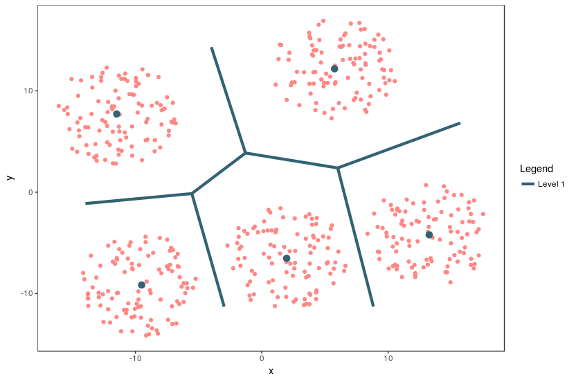

Quantization_Error

An example of 2 dimensional VQ is shown above

In the above image, we can see that there are 5 clusters/cells and each cells contain certain number of points. The centroid for each cluster is shown in blue. We can also call the centroids as codewords as they represent all the points in that cluster. The set of all codewords is called a codebook.

Now we want to calculate quantization error for each cluster. For the sake of simplicity, let’s consider only once cell having centroid `A` and `m` data points $F_t$ for calculating quantization error.

For each point, we calculate the distance between the point and the centroid.

$$d = ||A - F_t||_{p}$$

$$QE = \frac{1}{m}\sum_{t=1}^m||A-F_t||_{p}$$

Now, we take the mean of the distance of all m points. This gives us the average distance of a point in the cell from the centroid which we refer to as Quantization error. If the quantization error is higher than the given threshold, this means that the centroid/codevector is not a good representation for the points in the cell. Now we can cluster this points further and repeat the steps above.

Please note that the user can select mean, max or any custom function to calculate the quantization error. The custom function takes a vector of m value (where each value is a distance between point in `n` dimensions and centroids) and returns a single value which is the quantization error for the cell.

# Voronoi Tessellations

A Voronoi diagram is a way of dividing space into a number of regions. A set of points (called seeds, sites, or generators) is specified beforehand and for each seed there will be a corresponding region consisting of all points closer to that seed than to any other. The regions are called Voronoi cells. It is dual to the Delaunay triangulation.

## Sammon’s projection

Sammon projection is an algorithm that maps a high-dimensional space to a space of lower dimensionality by trying to preserve the structure of inter-point distances in high-dimensional space in the lower-dimension projection. It is particularly suited for use in exploratory data analysis. It is considered a non-linear approach as the mapping cannot be represented as a linear combination of the original variables. The centroids are plotted in 2D after performing Sammon’s projection at every level of the tessellation.

Denote the distance between $i^{th}$ and $j^{th}$ objects in the original space by $d_{ij}^*$, and the distance between their projections by $d_{ij}$. Sammon’s mapping aims to minimize the following error function, which is often referred to as Sammon’s stress or Sammon’s error:

$$E=\frac{1}{\sum_{i<j} d_{ij}^*}\sum_{i<j}\frac{(d_{ij}^*-d_{ij})^2}{d_{ij}^*}$$

The minimization can be performed either by gradient descent, as proposed initially, or by other means, usually involving iterative methods. The number of iterations need to be experimentally determined and convergent solutions are not always guaranteed. Many implementations prefer to use the first Principal Components as a starting configuration.

#### Example Usage 1

In this section, we will use the `Prices of Personal Computers` dataset. This dataset contains 6259 observations and 10 features. The dataset observes the price from 1993 to 1995 of 486 personal computers in the US. The variables are price,speed,ram,screen,cd,etc. The dataset can be downloaded from [here](https://github.com/thomaspernet/data_csv_r/blob/master/data/Computers.csv)

In this example, we will compress this dataset by using hierarhical VQ using k-means clustering and visualize the Voronoi tesselation plots using Sammons projection. Later on, we will overlay price variable as heatmap to generate further insights.

Here, we load the data and store into a variable `computers`.

```r
set.seed(420)

# Load data from csv files
computers <- read.csv("https://raw.githubusercontent.com/thomaspernet/data_csv_r/master/data/Computers.csv")
```

Let’s have a look at sample of the data

```r
head(computers)
```

[output not shown]

Now let us check the structure of the data

```r
str(computers)
```

[output not shown]

Let’s get a summary of the data

```r
summary(computers)
```

[output not shown]

Let us first split the data into train and test. We will use 80% of the data as train and remaining as test.

```r
no_of_points <- dim(computers)[1]
train_length <- as.integer(no_of_points * 0.8)

train_computers <- computers[1:train_length,]
test_computers <- computers[(train_length+1):no_of_points,]
```

K-means in not suitable for factor variables as the sample space for factor variables is discrete. A Euclidean distance function on such a space isn’t really meaningful. Hence we will delete the factor variables in our dataset.

Here we keep the original train_computers and test_computers as we will use price variable from this dataset to overlay as heatmap and generate some insights.

```r
train_computers <- train_computers %>% dplyr::select(-c(X,cd,multi,premium,trend))
test_computers <- test_computers %>% dplyr::select(-c(X,cd,multi,premium,trend))
```

Let us try to understand HVT function first.

```r
HVT(dataset, nclust, depth, quant.err, projection.scale, normalize = T, distance_metric = c("L1_Norm","L2_Norm"), error_metric = c("mean","max"))
```

Here I have explained all the parameters in detail

- **`dataset`** - Dataframe. A dataframe with numeric columns
- **`nlcust`** - Numeric. An integer indicating the number of clusters per hierarchy (level)
- **`depth`** - An integer indicating the number of levels. (1 = No hierarchy, 2 = 2 levels, etc …).
- **`quant.error`** - A number indicating the quantization error threshold. A cell will only breakdown into further clusters only if thje quantization error of the cell is above quantization error threshold.
- **`projection.scale`** - A number indicating the scale factor for the tesselations so as to visualize the sub-tesselations well enough.
- **`normalize`** - A logical value indicating if the columns in your dataset should be normalized. Default value is TRUE. The algorithm supports Z-score normalization.
- **`distance_metric`** - The distance metric can be `L1_Norm` or `L2_Norm`. `L1_Norm` is selected by default. The distance metric is used to calculate the distance between a `n` dimensional point and centroid. The user can also pass a custom function to calculate the distance.
- **`error_metric`** - The error metric can be `mean` or `max`. mean is selected by default. The `mean` will take mean of `m` values where each value is a distance between a point and centroid of the cluster. The `max` will return the max of `m` values. Moreover, the user can also pass a custom function to calculate the error metric.

First we will perform hierarchical vector quantization at level 1 by setting the parameter depth to 1. Here level 1 signifies no hierarchy. Let’s keep the no of clusters as 5.

```r
set.seed(420)

hvt.results <- list()

hvt.results <- muHVT::HVT(train_computers_df,nclust = 5,depth = 1,quant.err = 0.1,projection.scale = 10,normalize = T)
```

Now let’s try to understand plotHVT function. Here I have explained all the parameters in detail

```r
plotHVT(hvt.results, line.width, color.vec, pch1 = 19, centroid.size = 3, title = NULL)
```

- **`hvt.results`** - A list containing the ouput of HVT function which has the details of the tessellations to be plotted.
- **`line.width`** - A vector indicating the line widths of the tessellation boundaries for each level.
- **`color.vec`** - A vector indicating the colors of the boundaries of the tessellations at each level.
- **`pch1`** - Symbol type of the centroids of the tessellations (parent levels). Refer points. (default = 19)
- **`centroid.size`** - Size of centroids of first level tessellations. (default = 3)
- **`title`** - Set a title for the plot. (default = NULL)

Let’s plot the voronoi tesselation

```r
# Voronoi tesselation plot for level one
plotHVT(hvt.results,line.width = c(1.5), color.vec = c("#326273"))
```

[output not shown]

As per the manual, **`hvt.results[[3]]`** gives us detailed information about the hierarchical vector quantized data

Now let us understand what each column in the summary table means